# Evolution, diversity, and association analysis with R

M Timothy Rabanus-Wallace

# Introduction and setup

It’s time to put our R skills to work, using them to interpret genetic data and turn it into meaningful information. There will be a few new R tricks in here but mostly we will focus on thinking about the data.

Get set up with the IDE as you did in the previous session, and work in the document “workshop_002.R”. And once again, run the line of code already there to load all the required packages and datasets:

```r
source("/filer/projekte/ggr-course2020/r-source/genres_2020_bioinfo_setup_fns_data.R")
```

We worked with some *phenotype* data (height, yield, etc.) last time. Now, let’s begin by looking at how some *genotype* data might be handled in an R environment.

And since we have just finished generating some genotype data of our own, let’s work with that! We will need to first interpret the experimental outcomes and work out what the genotypes are. The data from the KASP experiments has been added to the setup so it is already loaded in your environment, in the variable `kasp`. Have a look at it first:

```r
kasp
```

Notice:

- Each row of data refers to a particular marker/sample combination, and has values representing the fluorescence of the amplified product generated by the primer sets designed to amplify from alleles 1 and 2.
- In the column “sample”, some values may appear as `<NA>`. These are control samples, which help to confirm to us that the samples have not been contaminated, and they indicate to us what a “zero” level of fluorescence looks like for this primer set.

I have written a function that will allow you to the fluorescences for any marker set you like, and see where a sample of interest falls. That will let you either make a determination what the genotype of the sample is—or decide it is a failed experiment. So that we can all work with the data, enter your determinations into [this shared online spreadsheet](https://docs.google.com/spreadsheets/d/1-TU8U3uqHlEtjXc701CLARu_hK__i8xNDH1Zlbd-F4I/edit?usp=sharing).

To run the plotting function, use this command:

```r
plot_KASP_output(  kasp=kasp,  marker="SNP_04" )
```

In the command, the argument `kasp=` provides the data source, and the argument `marker=` specifies which marker’s results should be plotted (start with the marker you genotyped, but feel free to explore the results for other markers too).

```r
plot_KASP_output(  kasp=kasp,  marker="SNP_04",  colour_samples=TRUE )
```

So … use those functions to get the plots for your markers, and fill in the relevant (“genotype”) entries in the google sheet (“1”" for allele 1, “2”" for allele 2, blank if the outcome is ambiguous).

Once we’re done, Tim will export the results to a shared folder, and then you will be able to load the data using this command:

```r
genotype_data <- read_KASP_genotypes()

genotype_data
```

## Genotype data with data.table

Let’s learn, and then use, a new trick. As we know, logical statements ask questions about data, and give back long lists of “TRUE”s and “FALSE”s. For example, we can create a vector of numbers and ask which are greater than 4:

```r
numbers  <- c(1,2,3,4,5,6,7,8,9)
numbers #run it to see what is in the vector
numbers > 4
```

Which gives “FALSE FALSE FALSE FALSE TRUE TRUE TRUE TRUE TRUE”. Now remember that the `sum()` function adds up the entries of a vector, for instance:

```r
sum(numbers)
```

… but what if `sum()` is not given numbers, but instead a logical vector? Well, in that case it automatically adds up all the times the vector includes TRUE! So if we put any logical statements inside the function `sum( .... )` we will get the answer to the questions “how many times is this true?” Have a look:

```r
sum(numbers > 4)
sum(numbers == 4)
sum(numbers == numbers)
```

Let’s use this trick to count the number of “missing” data points for each marker. This will give us an idea which markers are unreliable. Missing data are given the special symbol “NA”, and we are interested in counting all the “NA”s in the “genotype” column. The logical command to tell you if an entry in a vector is “NA” is `is.na()`. See how it works here:

```r
numbers_with_NAs <- c(1,2,3,4,NA,6,7,NA,9)
numbers_with_NAs
is.na( numbers_with_NAs )
sum( is.na(numbers_with_NAs) )
```

Take a minute to recall first the structure of a `data.table` command, and what they do. Here is the command again, and the diagram from the last workshop to help. Be sure to take note again of the `.( )` structure that occurs in the OUTPUT field, and the `by=` that we use in the GROUP_BY field to indicate the grouping variable.

> data_table_name[ SELECT , OUTPUT , GROUP_BY ]

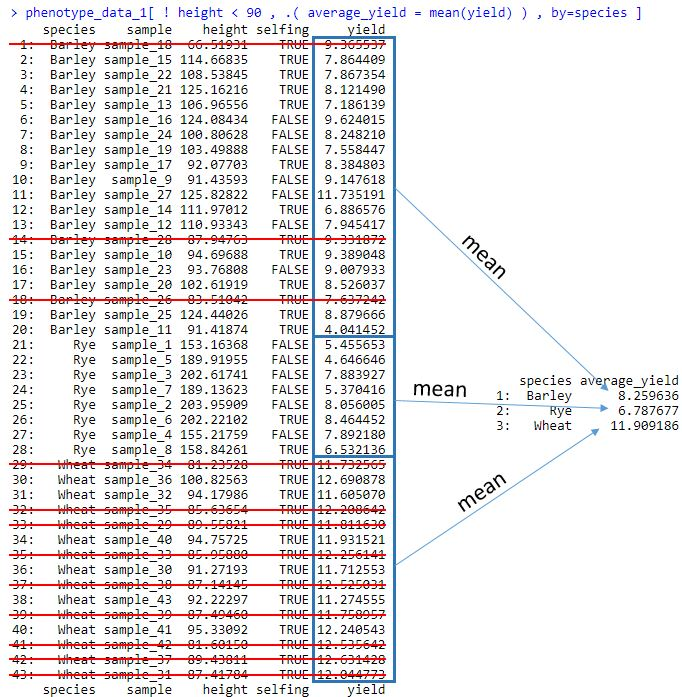

Let’s build up the command.

```r
#start with the basic structure
genotype_data[  ,  ,  ]

#THINK: Do we want to select any particular rows? (We don't, so the SELECT field stays blank)

#THINK: Do we want to output something? (Yes, so set up the output field with the ".( )" and name the output)
genotype_data[  , .( number_of_NA_genotypes =  ) ,  ]

#Fill in the command to produce what we want
genotype_data[  , .( number_of_NA_genotypes = sum(is.na(genotype)) ) ,  ]

#THINK: Do we want to produce this output for different groups? (Yes, we want to group them by marker, so set up the "by=" and the )
genotype_data[  , .( number_of_NA_genotypes = sum(is.na(genotype)) ) , by=marker ]
```

#### Exercises:

1. Write a command that produces two columns:
- A column `called n_genotypes_1` that records how many genotypes are “1”
- A column `called n_genotypes_0` that records how many genotypes are “0”
- - HINT: Remember to list the new columns inside the `.( )` in the OUTPUT field, separated by commas.
- - HINT: Remember the “is equal to” logical test uses `==`.
2. Modify the above command to produce these counts separately for each marker.
- - HINT: Use the GROUP_BY field.
3. **CHALLENGE!** (optional): The data.table `genotype_data` also has a column called *expected_genotype*, which gives the genotype based on previous work done at IPK. Can you write a command to calculate how many of the measured genotypes match the expected genotypes for each group?

Before we plot the genotypes, fill the missing data in based on previous work done at IPK. Just run this command to do it:

```r
genotype_data[ is.na(genotype) , genotype := genotype_expected ]
```

## Graphical genotypes with ggplot

To create a graphical genotype display, shows genotypes as coloured dots or squares arranged in a “grid” with marker positions lined up on the x-axis, and samples lined up along the y-axis. Once we refresh our ggplot syntax for a scatterplot, this should be easy.

> ggplot( data=<data.table name> , mapping=aes( x= , y= ) ) + geom_point()

So, `data=` gives the data source (`genotype_data` in this case), and the arguments inside `mapping=aes()` (as in `x=..., y=..., colour=...`) tell ggplot what to display on the plot. Let’s build this command up piece by piece as before:

```r
#Start with the structure!
ggplot( data=   , mapping=aes( x=   , y=   ) ) + geom_point()

#Fill in the data source
ggplot( data=genotype_data   , mapping=aes( x=marker , y=sample ) ) + geom_point()
```

Almost there! We just need to add another aesthetic for colour!

#### Exercise

- Add another aesthetic to the plot above that maps genotype to colour.

If you did that correctly you will have a command something like this:

```r
ggplot( data=genotype_data , mapping=aes( x=marker , y=sample , colour=genotype ) ) + geom_point()
```

Which works *quite* well, but not perfectly. The colours aren’t very clear. This is because `ggplot` sees that the genotypes are “1” and “0” and it assumes they are numbers along a scale and not separate categories. To fix it, specify that “genotype” should be a categorical variable by putting it inside the function `as.factor()` … like this:

```r
ggplot( data=genotype_data , mapping=aes( x=marker , y=sample , colour=as.factor(genotype) ) ) + geom_point()
```

So, based on what we just did in the lectures, let’s think about some of the phenomena we can see just by looking at the data in this form.

#### Exercises:

1. Look for linkage between the genotyped alleles at each locus. Scan the columns of dots (markers) and look for pairs of columns that have either the same pattern of red and blue, or the exact opposite pattern. If you can’t find a pair of loci with complete allelic linkage, can you find some that are close?
2. Think about the relatedness between individuals in the sample. Closely-related individuals have identical variants at most sites. Scan the rows (samples) to find pairs of rows with identical or nearly-identical genotypes.
3. Can you see any grouping among the genotypes?

## Genotypes as a window into deep history: Thinking about evolution

When we asked about relatedness and grouping of genotypes, we are really asking much more profound questions about the relatedness genetic grouping of individuals, which is a direct consequence of their evolutionary history.

In the lecture we talked about visualising genetic diversity intuitively using principal components analysis, and using the resultant PCA plots to speculate about possible evolutionary scenarios.

### Simulating evolution

We now have a short exercise designed to strengthen intuition about how different evolutionary histories lead to different patterns of diversity. You will actually simulate your own evolutionary scenarios in R using pre-loaded functions, and see how they look once represented in this way.

In the lecture we talked about how to set these up using a table. Here’s an example for you to start on. Notice writing a `data.table` into R is pretty much just like running any function (i.e., it has the structure `function_name( argument1 = ... , argument2 = ... )`), except the argument names are the column names, and the `...` is whatever you want to fill the columns with.

```r
events1 <- data.table(  event=c("split","size_change","split"),  generation=c(4,7,9),   population=c(1,2,1),   size=c(5,3,2)    )

events1
```

As we discussed in the lecture, the events table describses the evolutionary scenario we want to simulate. In this case, here is a phylogenetic depiction of the events described:

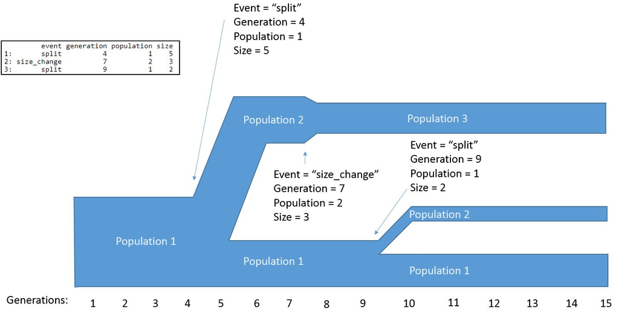

Run the simulation by giving the events list to the `sim_pop` function like this.

```r
simulation1 <- sim_pop(events=events1)
```

If done correctly, you’ll get a plot that shows the individuals in the population evolving, just as we requested! The dots represent individuals in a particular generation, while the lines represent the two parents of each individual.

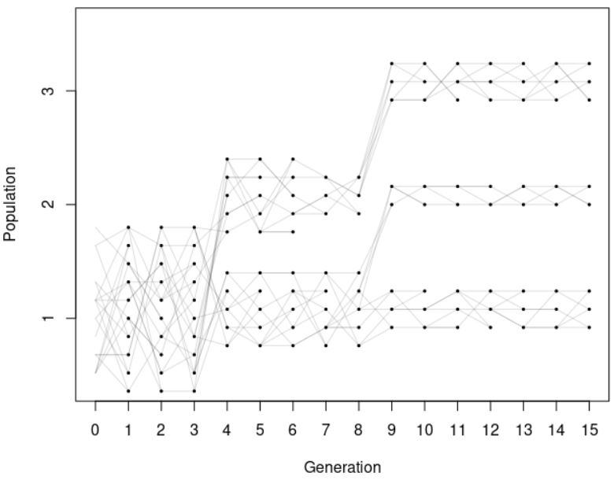

As you can see, the population splits and size changes represent the evolutionary scenario we described. Now, let’s look at the patterns of genetic diversity this scenario produced! I wrote some quick plotting functions for the course to save time.

```r
plot_simulated_genotypes(simulation1)
```

Once again, can you tell which individuals (rows) are closely related? Which are from which populations? Have a guess, then check by adding the argument `show_populations=TRUE`, to reveal (using shapes), which individuals are grouped.

```r
plot_simulated_genotypes(simulation1,show_populations=TRUE)
```

It should look pretty obvious now what the effect of split population histories is on the marker states. What about the PCA though? The function `plot_genetic_diversity()` can be used to represent the simulated genetic diversity in PCA form.

```r
plot_genetic_diversity(simulation1)
```

Remember:

- Tighter (less variable) clusters come from populations that have spent some time being a small size.
- Looser (more variable) clusters come from populations that have spent some time being a large size.
- Clusters that are close together represent populations that have split later in evolutionary time.
- Clusters that are very separate usually split early.

Since we split the population into three small populations, we will likely see three distinct sub-clusters. We also expect that the first two principal components will probably capture most of the variance. It’s a simple, clear, three-way split: we probably really need one or two dimensions (PC1 and PC2) to describe the genetic variation in the population adequately for most purposes.

This is what I actually got:

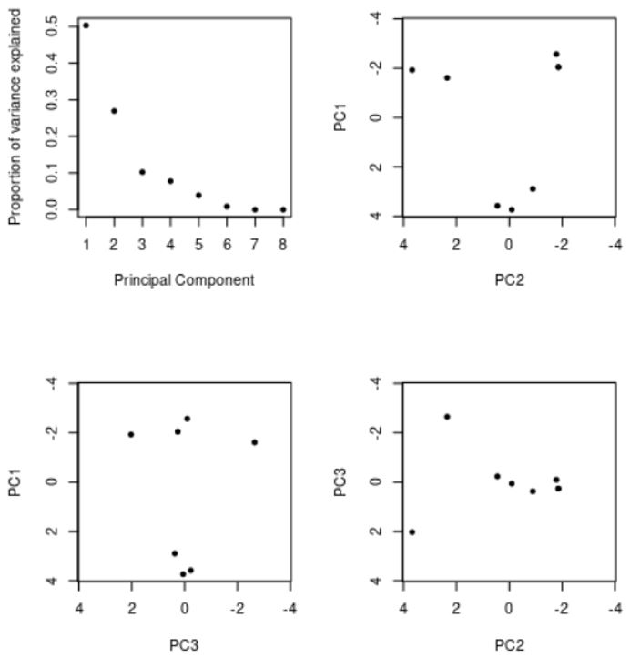

And I’ll add some annotation to help explain the interpretation:

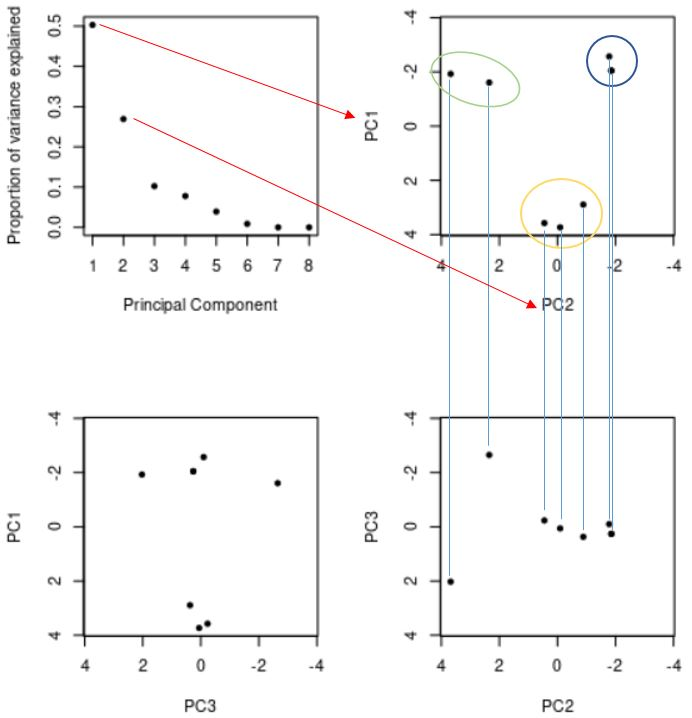

Notice:

- The first two PCs (PC1 and PC2) explain a lot more of the variance in the data than the next few PCs. That means samples separated along PC1 have a bigger evolutionary distance between them than samples separated along PC2.
- There are some pretty clear groups in PCA plot showing these two important PCs. These are probably our three sub-populations (circled).
- We can see where different samples are on different plots using the shared PCs. For example, PC2 is shown in both the plots on the right. Since they share the same position for PC2, I can see which ones correspond to each other (they are joined by blue lines to make it easier to see). In scientific presentations we sometimes use tricks with colour to help the viewer match samples between different PCA plots.
- By matching samples between PCA plots I can suggest a particular evolutionary history: PC1 (which explains the biggest variation) separates the green/blue clusters from the yellow cluster. So the biggest evolutionary split was between those. PC2 explains less variance, and it separates the green cluster from the blue. So that probably represents another population split, but a more recent one. Therefore, from the genetic data alone, we can guess the evolutionary history might have looked like this:

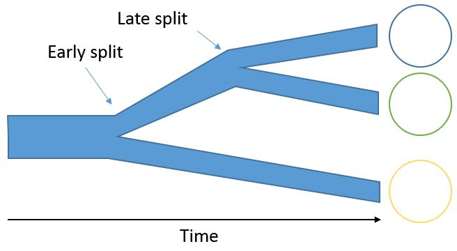

This is basically correct (it approximately matches what we originally simulated), although with this data set we can’t say much about the timing of the events or the sizes of the differenc sub-populations. But we worked out the basic picture of the evolutionary history *from genetic data alone*!, and that is what evolutionary inference from genetics is all about.

Look at your results (they will differ from mine a bit, there is a random component to the simulation). How many PCs are required to summarise most of the variation? Do you see distinct clusters? Can you guess which points come from what simulated sub-populations? Once you’ve guessed, you can actually reveal what the real sub-population structure was using the argument `colour_variable = "population"` in the function `plot_genetic_diversity()` like this:

```r
plot_genetic_diversity(simulation1,colour_variable = "population")
```

#### Exercise

1. Create an events table and run a simulation that includes at least two population split events and at least two size changes. Try to predict what the diversity will look like in a PCA plot. Check if your predictions are right using `plot_genetic_diversity()` (first with, and then without the argument `colour_variable = "population"`).
- - NOTE: Avoid making your total population bigger than about 50, it will run very slowly.
2. Interpret the following PCA representation of genetic diversity in a population:

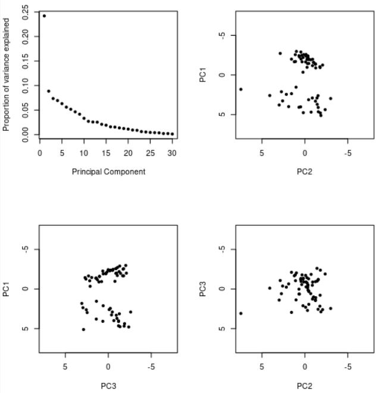

- Are distinct groups visible?
- What does this tell you about the time of splits between the groups?
- Based on the tightness of the clustering of each group and the amounts of variance explained by each PC, are there obvious differences in genetic variability among the clusters?
- What do could this tell you about the sizes of the different sub-populations during their evolutionary history?

### Evolutionary inference on real data (with help from simulations)

So, we know evolution can predict what we will see in PCA plots. Let’s work backwards and try to infer the evolution of our actual KASP-marker-genotyped dataset!

First we need to look at our genetic information in PCA form. Do that with:

```r
plot_genetic_diversity(genotype_data)
```

#### Exercise:

- Sketch an evolutionary tree that could explain the genetic diversity patterns you can see in the PCA plots.

## Attaching phenotype data

We have some phenotype data available for these samples, it is pre-loaded as a data.table called `phenotype_data`. Have a look:

```r
phenotype_data
```

As you can see, the phenotype information we have for each sample is stored in columns with names like “annuality” and “rachilla_hairs”. What do they mean?

- Latitude is the latitude at which the sample grows. In general, higher latitudes have colder winters.
- LT50, in the *cold_tolerance_LT50* column, is a measure of how well a sample adapts to cold. Lower values mean that a sample can better survive lower temperatures.
- Annuality refers to the time during which the variety can be sown (planted). Winter type barleys are more tolerant of cold.
- Spike length and awn length refer to the lengths of these parts:

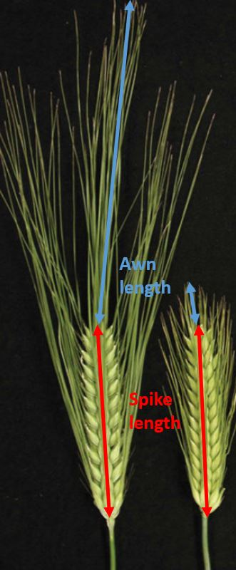

  Image from [Yuo et al., 2009](https://academic.oup.com/jxb/article/63/14/5223/537592)
- Awn texture relates to the presence or absence of microscopic barbs on the awns, that make the awns feel rough to touch:

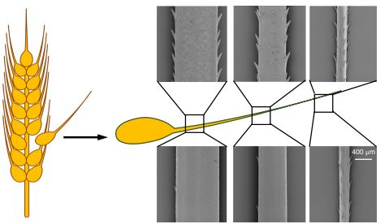

  Image from [Milner et al., 2019](https://www.nature.com/articles/s41588-018-0266-x)
- Finally, rachilla hairs issue from the rachilla. Rachilla are the tiny “stalks” that attach the florets (the individual barley flowers) to the main axis of the spike. These hairs can be long or short:

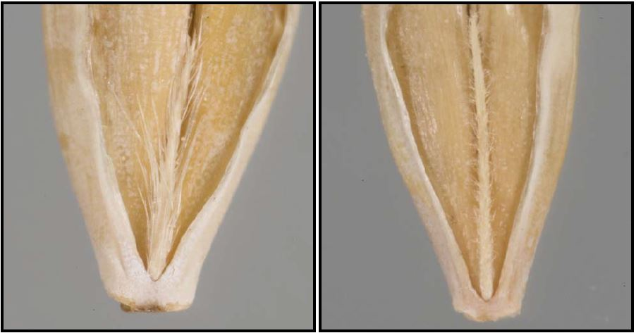

  Image from [Russell and Paynter, 2009](https://www.researchgate.net/publication/274077770)

#### Exercises

1. Write a ggplot command that will help you see if there is a relationship between awn length and spike length.
- HINT: I would use a scatterplot (`geom_point()`)
2. HOMEWORK QUESTION: There are at least two explanations for why grasses have awns. Firstly, they are very unpleasant for a mammal to eat, because they splinter into pieces and the barbs make them stick in the animal’s throat. Secondly, florets that fall to the ground contract and expand with the heat, and this movement of the awns helps them to bury themselves in the soil. Think about your plot in relation to these two explanations of why awns exist. what would you predict about the awn length / spike length relationship based on each one? Do the results suggest one explanation is better than the other?

### The glorious `merge` feature!

We want to intepret our phenotypic data in the context of genetic data, we will have to combine them into one table. This is where the *merge* feature of `data.table`s is helpful. Each row of `genotype_data` corresponds to a sample, listed in a column called *sample*. And each of these samples also appears somewhere in `phenotype_data`, also in a column called *sample*. What we really want to do, is to take each sample name in the *sample* column of `genotype_data`, search the table `phenotype_data` for a row where the sample name matches, and then add the information from that row to `genotype_data`. In a way, it is like the sample names in `genotype_data` are being used to SELECT the rows of `genotype_data` to add to itself.

And that’s why we use the SELECT field for merging. We simply put `genotype_data` into the SELECT field of `phenotype_data`! We also explicitly tell it that we want the selection process to use the information in the columns named *“sample”* using the argument `on="sample"`:

```r
phenotype_data[ genotype_data , on="sample" ] #this just prints out the result of the merge on the screen

combined_data <- phenotype_data[ genotype_data , on="sample" ] #this writes the result to a variable (`combined_data`) so we can use it later
```

## Phenotypes and evolution

As we know, evolution by natural selection works because an individual’s phenotype affects its ability to reproduce and pass alleles on to the next generation. But selection doesn’t always act in exactly the same way for every individual. For example, individuals living in a sub-population living in a windy area might pass on more genes that make them short (so they don’t blow over too easily). But individuals in another sub-population which doesn’t experience much wind might be fitter if they grow tall, which mean they can suck up as much light energy as possible and use that energy for making seeds.

Let’s think about the phenotypic information we have, and how it might relate to evolutionary history. To do that, we can take our PCA (our window into the evolutionary relationships), and superimpose information about phenotypes onto it. We do this using the same function `plot_genetic_diversity()`, and provide column names for the colour variable with the argument `colour_variable=`. To remind yourself what phenotype data we have, you can just run the name of the data.table (`combined_data`) and look at the column names.

For example, we could examine rachilla hairs like this:

```r
plot_genetic_diversity(combined_data,colour_variable="rachilla_hairs")
```

I got a result like this:

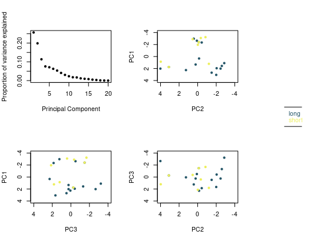

As we can see in the top-right PCA plot, long rachilla hairs do seem a bit more common in the lower cluster than in the upper cluster. Perhaps this could mean that one sub-population grows in areas where long rachilla hairs are more useful than they are in the areas that the other sub-population grows in? That would mean rachilla hairs are a consequence of the groups’ evolutionary histories. However, this could also just be a random result (which is more likely). This is one of the problems with small data sets like this: it can be hard to say with certainty whether results really mean anything or not. Perhaps there are other phenotypic traits that correlate better.

Your turn:

#### Exercises:

1. Plot the genetic diversity of the KASP-marker genotyped population, with the latitude shown in colour.
- - Do closely-related individuals tend to live at similar latitudes?
- - Does the latitude information help to divide large or ambiguous clusters into more clear groups? If so, update the evolutionary tree you sketched in a previous exercise—can you now specify that one of the sub-populations in the last sketch might actually be two *sub-*sub-populations?
- - There are two broad ways that populations become genetically isolated and form sub-populations:
- - 1. A sub-population expands into a different location, then gradually becomes genetically separated from the parent population.
- - 2. A process such as polyploidy creates a new sub-population that cannot interbreed with the parent population, and this new population becomes genetically isolated while inhabiting the same area as the parent population. What do the latitudes of the various sub-populations tell you about the role of geography in the evolution of these sub-populations? Is splitting method (1) or (2) more likely? What would you expect to see in the plot if your answer was wrong?
- - On your phylogeny sketch, mark where in the evolutionary histories migrations into new latitudes are likely to have occurred.
2. Plot the PCA and colour the points according to cold tolerance (LT50). To answer the questions, it will be helpful to have the commands to produce both plots in your working document, so that you can flip between one and the other.
- - What do the results say about the relationship between cold tolerance and latitude?
- - On your phylogeny sketch, indicate which sub-populations have high, low, and medium cold tolerance.
- - On your phylogeny sketch, mark where in the evolutionary histories increases in cold tolerance are likely to have occurred.
3. Do you think that, over evolutionary time, this species migrated north from low latitudes, or south from high latitudes? Tell Tim which you think it is.

*Have a coffee! One short section to go for today.*

## SNP associations with phenotypes

As dicussed in the lecture, genotypes are both *caused by* and *cause* evolution. We spent the day so far thinking about what evolutionary history does to genotype data (and how to work backwards from the genotype data to the history). But when a genotype causes a phenotype, then this affects the fitness of the individuals, and this affects the way evolution occurs.

One such example, is the cold tolerance we just studied. At some stage, a genotypic change—a mutation affecting cold tolerance—must have made such a difference the survival of individuals in a sub-population, that they all developed similar levels of cold tolerance.

If we are growing barley plants and we want them to be cold tolerant, then it would be a great advantage to know exactly *which* genetic changes are having this effect—then we can use the same genetic variants to produce cold-tolerant varieties!

To do this, we find correlations between genotypes at particular sites and phenotypes that suggest the site is linked to the cause of the phenotype. In some cases, the genotype observed at the correlating site might not just be *linked* to the phenotype—it might actually be a *cause* of the phenotype—but establishing true causality requires a *lot* of experimental validation. Finding genotype-phenotype correlations requires the use of some statistics, which is what we will try to understand better in this session.

First, let’s revisit the problem of genotype-phenotype correlations caused by population structure, by looking at our KASP data. We could ask about cold tolerance as discussed in the previous section, and investigate it naively by viewing the graphical genotypes in the context of how cold tolerant the samples are. To do this, I just used the high-cold-tolerance and low-cold tolerance samples, indicated by shape. Have a look at the results.

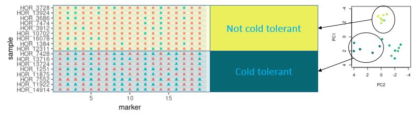

What we are looking for is sites (columns) where the genotypes (colours) are almost all one state (colour) for the cold tolerant group, and almost all in a different state for the non-cold-tolerant group. This would point to linkage (or causation) between the site and the phenotype. I can see one here:

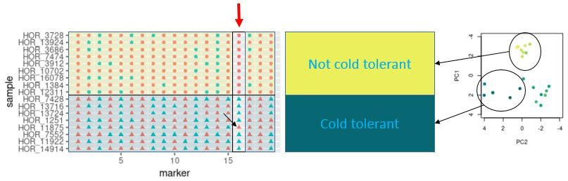

Only one sample’s genotype (black arrow) disagrees with the general pattern: The green allele occurs in cold tolerant samples, and the red allele is in non-cold-tolerant samples.

But here’s the problem: I can find many other sites where the pattern (or “correlation” to be precise) is almost as good …

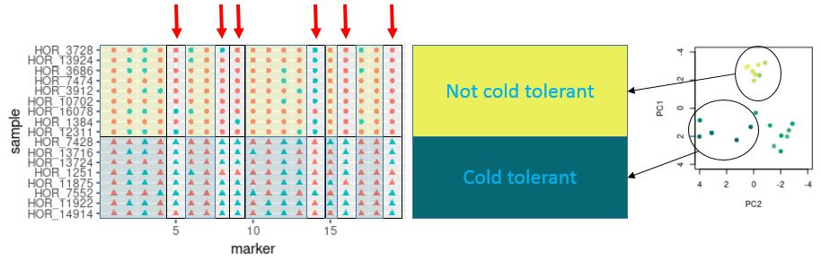

If you look at the original graphical genotypes again, you’ll easily see why: because sub-populations are generally genetically similar. So if we are going to find strong associations, we need to account for population in our statistical method.

### Linear models

First, let’s get a feel for one of the most popular statistical frameworks that exists for investigating associations when there are many factors involved, linear modelling. As we said in the lecture, *linear models* are about checking how well some outcome can be predicted by adding together different factors. If a factor can help the final sum get closer to the real result, then there is a chance that factor has an important influence on determining the outcome.

Here is a tool that will help you get a feel for linear models, and how we can use them to control for factors like population structure. Mostly, scientists use software programs to fit models automatically but to really understand the process, it’s a good exercise to fit them yourself. We will fit a linear model that tries to predict the height of some hypothetical rye samples, based on three factors:

- The amount of fertiliser that is applied to them.
- The genotype of a SNP (we will try it with two different SNPs actually, one at a time. This is quite common in genetic association studies.)
- The subpopulation the sample is in.

Start with this command using the function `check_fit_fertiliser()`.

- NOTE: Previously all the R commands have been one line long. This time, I’ve written this function over three lines. This is allowed because when R sees an open bracket (i.e. `(` or `{` or `[`), it expects a close bracket (`)` or `}` or `]`) … so it will just keep reading lines until all the brackets are closed and the command is complete.

```r
check_fit_fertiliser(
  guess_eff_fertiliser = 1 #this is YOUR guess of the effect fertiliser has on the height
)
```

The result will look like this:

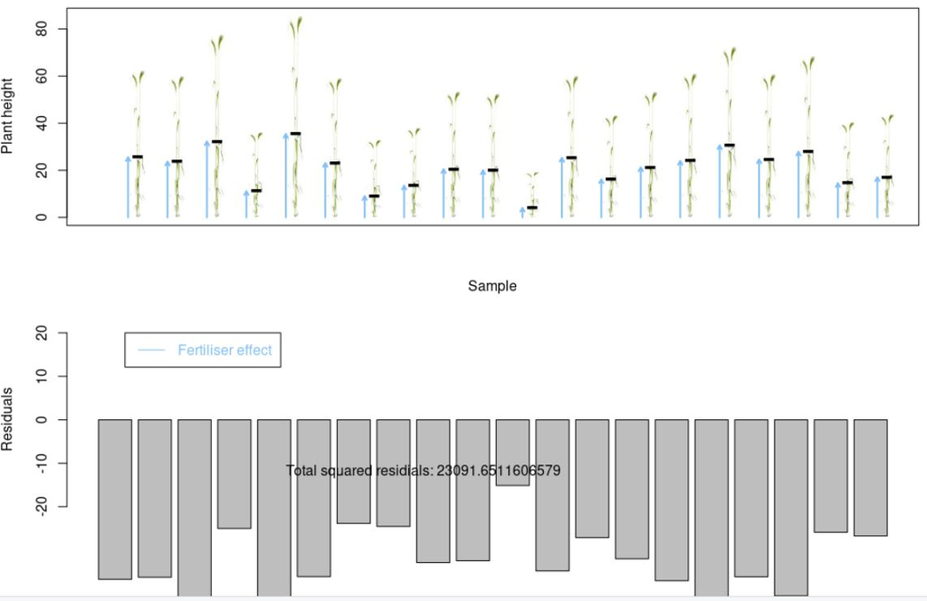

At the top we see a “field” of rye plants. The black bars represent the height estimated by the model. If the fit is very good, the black bars will be at the exact same height as the plant. The blue arrows show the contribution to the model’s prediction made by different factors (in this case, there is only one factor, fertiliser). The lower panel shows the differences (or *residuals*) between the predicted heights and the real heights (and the text tells you the total squared sum of these differences). If the fit is good, the bars will be small, and the total squared residuals will be as low as possible. This is a bad fit. Some models will simply never fit well, but with this one I think we can improve the fit.

How? We need to add more “weight” to the influence of fertiliser. In maths-speak, this “weight” given to each factor is called a co-efficient. The coefficient is currently set to 1. But I think if we tripled the height of each arrow, we’d get a better fit, so let’s try it at 3:

```r
check_fit_fertiliser(
  guess_eff_fertiliser = 3
)
```

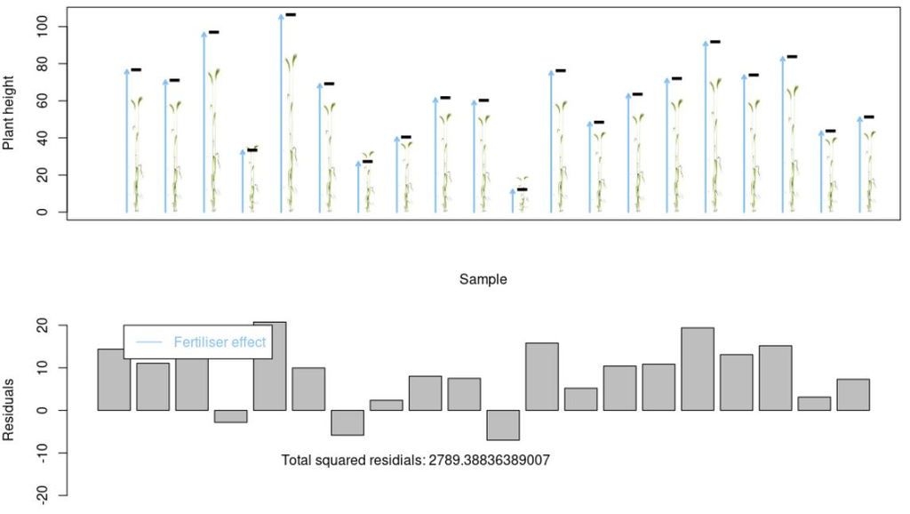

See how that made the influence of fertiliser three times bigger, and now our residuals are smaller (also some are negative because the prediction is not as high as the plant.)

#### Exercise

- Try to get the best fit possible for the fertiliser-only model by changing the coefficient for fertiliser effect. Limit yourself to five tries (no cheating!) We will see who can get the best fit.

Ok, time to get genetics involved. The function `check_fit_fertiliser_SNP1()` adds a factor for a SNP at some site. If a plant has this SNP, it will get an extra factor added. Now we are allowed to guess two coefficients!

```r
check_fit_fertiliser_SNP1(
  guess_eff_fertiliser = 2.2,
  guess_eff_SNP1 = 20
)
```

#### Exercise

- Try to optimise the fit by altering the coefficients for fertiliser and SNP1. Remember, you can use decimals to make fine adjustments, and also, a negative coefficient will reverse the direction of the effect!

So, remember how we established that SNP effects are affected by population structure? To add another factor for subpopulation, use this function:

```r
check_fit_fertiliser_SNP1_subpopulation(
  guess_eff_fertiliser = 2.2,
  guess_eff_SNP1 = 20,
  guess_eff_subpopulation = 1
)
```

#### Exercise

- Optimise the fit again.
  - Hint: You can get this one so good that the total squared residuals are less than 50.

Ok, so if you managed to optimise those last two, you’ll have realised that without accounting for the population effect, the SNP effect was hard to estimate. Only once the population factor is accounted for can you really get accurate with the other effects. This is a good example of why genebank genomics is important! Without big data sets from genebanks, it would be impossible to add in enough relevant factors to models, and it would be impossible to accurately uncover subpopulation structure to make the models work!

#### Exercise

- Do the same process for SNP2. First fit the model with SNP2 using the function `check_fit_fertiliser_SNP2()` (fill in the arguments just like with `check_fit_fertiliser_SNP1()` but change “SNP1” to “SNP2”). Then do a fit that includes a subpopulation factor, using `check_fit_fertiliser_SNP2_subpopulation()`

So, which got the best fit? And how did the coefficient for SNP2 change? As you know, a low coefficient means the factor is not influencing the outcome very much. So if it was low in one model and high in another … this should make you cautious about whether models are telling the truth—or whether they are just lacking the right combinations of factors to describe it properly.

Since it’s the end of the day, let me freak you out with some slightly more advanced R code. You don’t need to understand this code! Just run it. It is designed to show you the power of R by finding the optimal coefficients for you! I will use the function `optim()` to do it for both the models you just fitted. But so that you don’t see the results too soon, I’ll make you scroll down a bit first. Ok, start scrolling.

Keep going…  
Not long now …

```r
optim(c(2,18),function(x){
  check_fit_fertiliser_SNP2(
    guess_eff_fertiliser = x[1],
    guess_eff_SNP2 = x[2]
  )
})

optim(c(2,18,10),function(x){
  check_fit_fertiliser_SNP2_subpopulation(
    guess_eff_fertiliser = x[1],
    guess_eff_SNP2 = x[2],
    guess_eff_subpopulation = x[3]
  )
})
```

The output without subpopulation information looks like this:

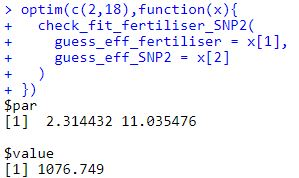

Where the numbers under “$par” are the best possible coefficients for fertiliser (left), and SNP2 (right). And under “$value” we see the best total squared residuals.

The output with subpopulation information:

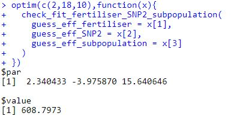

Here, “$par” shows us a third number, the best possible coefficient for the subpopulation factor. And look! The coefficient for SNP2 has become much smaller (-3.975870), while the coefficient for subpopulation (15.640646) has become much more impressive than the coefficient for SNP2 used to be. AND, the model fits much better—the squared residials went from over 1000, to 608.7973. Lucky we included population structure in the model, or else, we would go away thinking we had found a genetic association, when really there is none! This is not the case for SNP1, where adding population structure made the fit better, but the SNP effect stayed about the same.

Ok, that’s all for today. Tomorrow we will change direction and look at some cutting edge sequencing data. Well done!